**Data605-Assignment3**

**Hazal Gunduz**

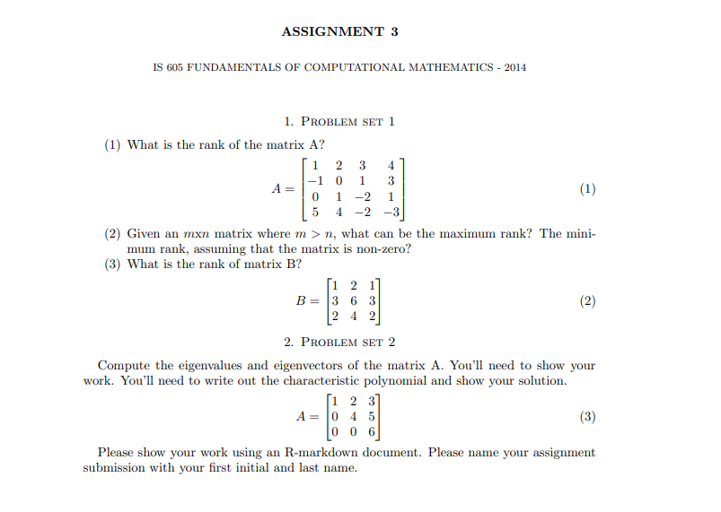

```r
library(knitr)
knitr::include_graphics("/Users/otheraccount/Downloads/assignment3.png")
```

**1. Problem Set 1**

**1.1: What is the rank of the matrix A?**

```r
A <- matrix(c(1,2,3,4,-1,0,1,3,0,1,-2,1,5,4,-2,-3), nrow = 4, ncol = 4, byrow = T)
A
```

```
##      [,1] [,2] [,3] [,4]
## [1,]    1    2    3    4
## [2,]   -1    0    1    3
## [3,]    0    1   -2    1
## [4,]    5    4   -2   -3
```

```r
dim(A)
```

```
## [1] 4 4
```

As we see from above matrix, it’s dimension is (4x4) matrix, therefore it rank is 4.

**1.2: Given an mxn matrix where m > n, what can be the maximum rank? The minimum rank, assuming that the matrix is non-zero?**

Given m x n matrix where m > n the max rank of that matrix will be n, the rank of a matrix cannot be greater than the smallest dimension of the matrix. And assuming the matrix is non-zero, the minimum rank of this matrix will be 1.

**1.3: What is the rank of matrix B?**

```r
B <- matrix(c(1,2,1,3,6,3,2,4,2), nrow = 3, ncol = 3, byrow = T)
B
```

```
##      [,1] [,2] [,3]
## [1,]    1    2    1
## [2,]    3    6    3
## [3,]    2    4    2
```

```r
det(B)
```

```
## [1] 0
```

The determinate of this matrix is 0. And at least one of the rows or columns is dependent one another. So row 2 = row 1 + row 3 and 2 x row 1 = row 3. The rank of this matrix is 1.

**2. Problem set 2**

**Compute the eigenvalues and eigenvectors of the matrix A.You’ll need to show your work.You’ll need to write out the characteristic polynomial and show your solution.**

Ax = $\lambda$x

det(A − I$\lambda$) = 0

(1 − $\lambda$)((4 − $\lambda$)(6 − $\lambda$)) + 2(0 − 0) + 3(0 − 0) = 0

(1 − $\lambda$)(4 − $\lambda$)(6 − $\lambda$) − 0 + 0 = 0

(1 − $\lambda$)(24 − 4$\lambda$ − 6$\lambda$ + $\lambda^2$) = 0

(1 - $\lambda$)(24 − 10$\lambda$ + $\lambda^2$) = 0

24−10$\lambda$ + $\lambda^2$ − 24$\lambda$ + 10$\lambda^2$ − $\lambda^3$ = 0

−$\lambda^3$ + 11$\lambda^2$ − 34$\lambda$ + 24 = 0

$\lambda^3$ − 11$\lambda^2$ + 34$\lambda$ − 24 = 0

$\lambda^2$($\lambda$ − 11) + 2(17$\lambda$ − 12) = 0

```r
A <- matrix(c(1,2,3,0,4,5,0,0,6), nrow = 3, ncol = 3, byrow = T)
A
```

```
##      [,1] [,2] [,3]
## [1,]    1    2    3
## [2,]    0    4    5
## [3,]    0    0    6
```

**Eigen values and vectors:**

```r
eigen(A)
```

```
## eigen() decomposition
## $values
## [1] 6 4 1
##
## $vectors
##           [,1]      [,2] [,3]
## [1,] 0.5108407 0.5547002    1
## [2,] 0.7981886 0.8320503    0
## [3,] 0.3192754 0.0000000    0
```